# Homwework 12

Karolina Gajewska

Linear models with fixed and random effects

## Task

Try two models: simple linear regression model with just one dependent variable and a model which takes into account spatial structure of measurements (variables east and north).

Compare these two models and answer the question: is there a significant relation between variables thick (y) and soil (dependent variable)?

## Dataset

```r
spdata <- read.table("http://www.ats.ucla.edu/stat/r/faq/thick.csv", header = T, sep = ",")
head(spdata)
```

```
##   X east north thick     soil dummy
## 1 1  0.7  59.6  34.1 3.635764     1
## 2 2  2.1  82.7  42.2 3.502083     1
## 3 3  4.7  75.1  39.5 3.946545     1
## 4 4  4.8  52.8  34.3 2.941715     1
## 5 5  5.9  67.1  37.0 3.866264     1
## 6 6  6.0  35.7  35.9 3.018548     1
```

## Model 1 : simple linear regression model

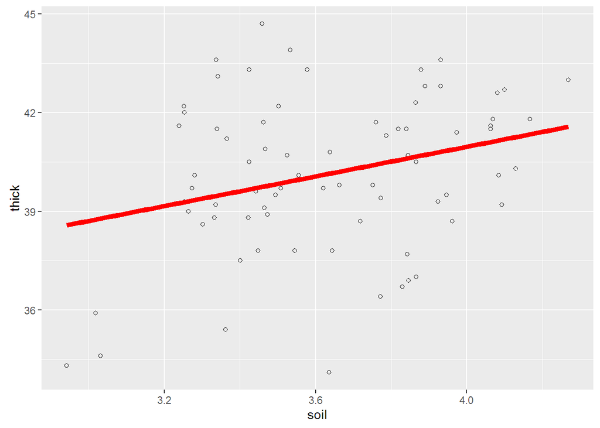

```r
library(ggplot2)

ggplot(spdata, aes(x = soil, y = thick)) +
      geom_point(shape = 1) +
      geom_smooth(method = lm, se = FALSE, color="red", size=2)
```

```r
Regmodel <- lm(thick~ soil, data=spdata)
summary(Regmodel)
```

```
##
## Call:
## lm(formula = thick ~ soil, data = spdata)
##
## Residuals:
##     Min      1Q  Median      3Q     Max
## -6.0414 -1.1975  0.0876  1.4836  4.9584
##
## Coefficients:
##             Estimate Std. Error t value Pr(>|t|)
## (Intercept)  31.9420     3.1570  10.118 1.54e-15 ***
## soil          2.2552     0.8656   2.605   0.0111 *
## ---
## Signif. codes:  0 '***' 0.001 '**' 0.01 '*' 0.05 '.' 0.1 ' ' 1
##
## Residual standard error: 2.278 on 73 degrees of freedom
## Multiple R-squared:  0.08508,    Adjusted R-squared:  0.07254
## F-statistic: 6.788 on 1 and 73 DF,  p-value: 0.01111
```

## Model 2: from page with hints

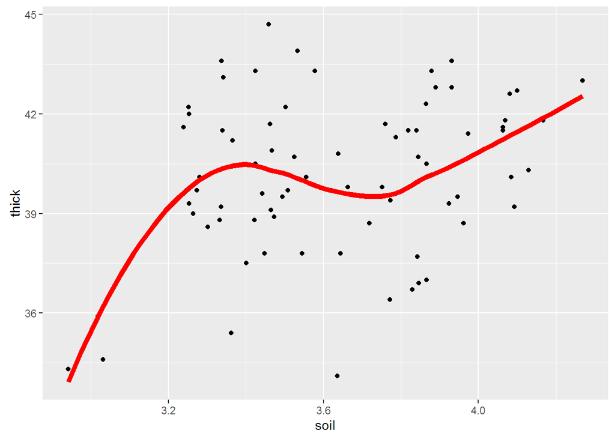

```r
ggplot(spdata, aes(soil, thick)) +
  geom_point() +
  geom_smooth(se=FALSE, color="red", size=2)
```

```r
library(nlme)
soil.model <- lme(fixed = thick ~ soil, data = spdata, random = ~ 1 | dummy, method = "ML")
summary(soil.model)
```

```
## Linear mixed-effects model fit by maximum likelihood
##  Data: spdata
##        AIC      BIC    logLik
##   342.3182 351.5881 -167.1591
##
## Random effects:
##  Formula: ~1 | dummy
##          (Intercept) Residual
## StdDev: 4.815352e-05 2.247569
##
## Fixed effects: thick ~ soil
##                Value Std.Error DF   t-value p-value
## (Intercept) 31.94203 3.1569891 73 10.117878  0.0000
## soil         2.25521 0.8655887 73  2.605407  0.0111
##  Correlation:
##      (Intr)
## soil -0.997
##
## Standardized Within-Group Residuals:
##         Min          Q1         Med          Q3         Max
## -2.68798974 -0.53279498  0.03896491  0.66007203  2.20612991
##
## Number of Observations: 75
## Number of Groups: 1
```

Despite the fact, that the relation between thick and soil doesn’t seem to be linear, Model 1 and Model 2 show that the relation between soil and thick is significant.

## Spatial correlation for “thick”

```r
library(ade4)
mantel.rtest(dist(spdata[,2:3]), dist(spdata$thick))
```

```
## Monte-Carlo test
## Observation: 0.1925625
## Call: mantel.rtest(m1 = dist(spdata[, 2:3]), m2 = dist(spdata$thick))
## Based on 99 replicates
## Simulated p-value: 0.01
```

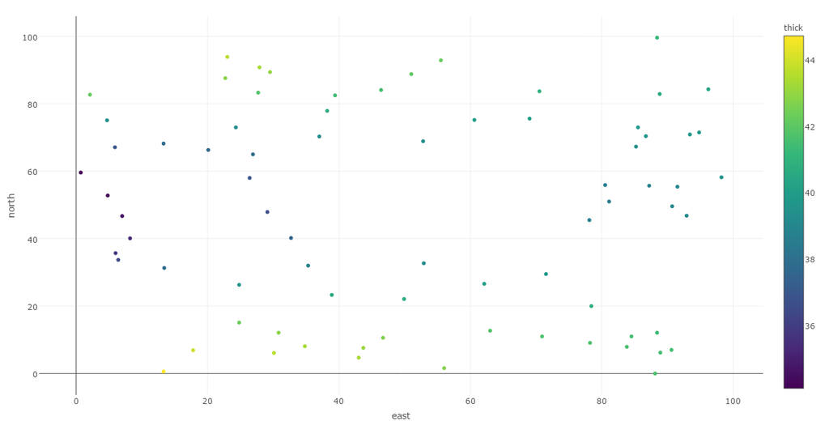

Based on this graph, we can say that the points which are in a similar location, have similar values for thick.

## Model with spatial correlation structures

```r
soil.gau <- update(soil.model, correlation = corGaus(1, form = ~ east + north), method = "ML")
summary(soil.gau)
```

```
## Linear mixed-effects model fit by maximum likelihood
##  Data: spdata
##        AIC      BIC    logLik
##   91.50733 103.0948 -40.75366
##
## Random effects:
##  Formula: ~1 | dummy
##          (Intercept) Residual
## StdDev: 8.287384e-05 2.088385
##
## Correlation Structure: Gaussian spatial correlation
##  Formula: ~east + north | dummy
##  Parameter estimate(s):
##    range
## 20.43725
## Fixed effects: thick ~ soil
##                Value Std.Error DF  t-value p-value
## (Intercept) 40.32797 0.5877687 73 68.61197  0.0000
## soil         0.00348 0.0160363 73  0.21693  0.8289
##  Correlation:
##      (Intr)
## soil -0.102
##
## Standardized Within-Group Residuals:
##        Min         Q1        Med         Q3        Max
## -2.9882504 -0.7133770 -0.1146244  0.6745690  2.0877373
##
## Number of Observations: 75
## Number of Groups: 1
```

Now we have very high p-value, so soil is not significant.

## Conclusions

Incorporating the Gaussian correlation structure in model, we can observe that soil is not a statistically significant predictor of thick. Without the spatial structure, this relationship becomes is significant.